# HitPredictionModel

### College Baseball Hit Prediction Model

- My github: https://github.com/trentbellinger

```python
import pandas as pd
import numpy as np
import matplotlib.pyplot as plt
import seaborn as sns
from sklearn.model_selection import train_test_split, RandomizedSearchCV, StratifiedKFold
from sklearn.feature_selection import RFECV
from sklearn.ensemble import RandomForestClassifier
from sklearn.metrics import classification_report, roc_curve, auc
```

- Read in the data and subset it to only include necessary columns.

```python
df = pd.read_csv("BaseballData.csv")
# keep only balls in play and columns related to the hit
df = df.loc[(df["PitchCall"] == "InPlay") & ~df["PlayResult"].isin(["Undefined", "Undefined "]),
            ["PlayResult", "ExitSpeed", "Angle", "Direction", "HitSpinRate", "SpinRate", "VertApprAngle",
             "HorzApprAngle", "Bearing", "HangTime"]]
# encode PlayResult column to be 0 for outs and 1 for hits
df.loc[df["PlayResult"].isin(["Error", "FieldersChoice", "FlyBall", "Sacrifice"]), "PlayResult"] = "Out"
df.loc[df["PlayResult"] != "Out", "PlayResult"] = "1"
df.loc[df["PlayResult"] == "Out", "PlayResult"] = "0"
df["PlayResult"] = df["PlayResult"].astype(int)

df.dropna(inplace = True)
df.reset_index(drop=True, inplace=True)

print("Number of observations:", df.shape[0])
df.head()
```

```
Number of observations: 3858
```

|  | PlayResult | ExitSpeed | Angle | Direction | HitSpinRate | SpinRate | VertApprAngle | HorzApprAngle | Bearing | HangTime |
| --- | --- | --- | --- | --- | --- | --- | --- | --- | --- | --- |
| 0 | 1 | 68.84125 | 22.265221 | -2.200403 | 2379.388675 | 1887.679618 | -5.172261 | 1.442790 | 3.111771 | 3.015233 |
| 1 | 0 | 46.06531 | 33.152094 | -31.472646 | 3634.521558 | 2003.872557 | -5.846822 | -0.709657 | -38.591008 | 2.324241 |
| 2 | 0 | 89.01811 | 1.042833 | 1.424267 | 1340.358271 | 2093.036282 | -5.122283 | 0.417104 | 2.740897 | 0.456372 |
| 3 | 1 | 98.00197 | 11.799976 | 3.113313 | 3079.098048 | 2533.351687 | -5.867873 | 1.012630 | 8.743531 | 2.056249 |
| 4 | 1 | 93.17167 | 14.811631 | -8.176319 | 1923.425695 | 1569.769999 | -7.226433 | -0.400234 | -16.450441 | 2.737525 |

- Check the relationship between hits, launch angle, and exit speed.

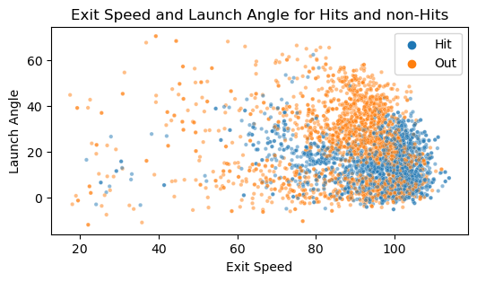

```python
plt.figure(figsize=(6, 3))
sns.scatterplot(x = df['ExitSpeed'], y = df['Angle'], hue = ["Out" if x == 0 else "Hit" for x in df["PlayResult"]], s = 10, alpha = 0.5)
plt.xlabel("Exit Speed")
plt.ylabel("Launch Angle")
plt.title("Exit Speed and Launch Angle for Hits and non-Hits")
plt.show()
```

- There is a clear relationship between hits and launch angle and exit speed. The points with higher exit speed and launch angle between 10 and 20 seem the most likely to be hits.
- We now split the data into train and test.

```python
X = df.drop(["PlayResult"], axis = 1)
y = df["PlayResult"]
X_train, X_test, y_train, y_test = train_test_split(X, y, test_size = 0.2, random_state = 42, stratify = y)
X_train.reset_index(drop=True, inplace=True)
X_test.reset_index(drop=True, inplace=True)
y_train.reset_index(drop=True, inplace=True)
y_test.reset_index(drop=True, inplace=True)
```

- Perform variable selection using recursive elimination and cross validation.

```python
# initialize a random forest model and use recursive elimination
rf = RandomForestClassifier(random_state=42)
rfecv = RFECV(estimator = rf, step = 1, cv = StratifiedKFold(5), scoring = 'accuracy')
rfecv.fit(X_train, y_train)

# get selected features
selected_features = X_train.columns[rfecv.get_support()]
print("Selected Features:", [i for i in selected_features])

# update the train and test sets to only include selected columns
X_train = X_train[selected_features]
X_test = X_test[selected_features]
```

```
Selected Features: ['ExitSpeed', 'Angle', 'HitSpinRate', 'Bearing', 'HangTime']
```

- We will now perform hyperparameter tuning using randomized search with cross validation.

```python
def rf_randomized_cv(model):
    # define the parameters to be tested
    param_grid = {
        'bootstrap':[True, False],
        'max_depth':[i * 5 for i in range(1, 21)] + [None],
        'max_features':['auto', 'sqrt', 'log2', 2, 3, 5, 8, 10, 12, 15, 17],
        'min_samples_leaf':[i for i in range(2, 21)],
        'min_samples_split':[i for i in range(1, 21)],
        'n_estimators':[i * 50 for i in range(1, 21)],
        'criterion':['gini', 'entropy']
    }
    # perform randomized search with cross-validation
    random_search = RandomizedSearchCV(estimator = model, param_distributions = param_grid, n_iter = 100, cv = StratifiedKFold(5),
                                       n_jobs = -1, scoring = "accuracy", random_state = 42)
    random_search.fit(X_train, y_train)
    return random_search.best_params_

params = rf_randomized_cv(rf)
print("Best parameters:")
params
```

```
Best parameters:
```

[output not shown]

- Fit the model and output the confusion matrix.

```python
rf = RandomForestClassifier(random_state = 42, **params)
rf.fit(X_train, y_train)
test_preds = rf.predict(X_test) # get the predictions for the test data
pd.crosstab(pd.Series(test_preds, name = "Predicted"), pd.Series(y_test, name = "Actual"))
```

| Actual Predicted | 0 | 1 |
| --- | --- | --- |
| 0 | 372 | 68 |
| 1 | 52 | 280 |

- It seems like the model performs relatively well based on the confusion matrix. Let's look at more statistics.

```python
print(classification_report(test_preds, y_test))
```

```
              precision    recall  f1-score   support

           0       0.88      0.85      0.86       440
           1       0.80      0.84      0.82       332

    accuracy                           0.84       772
   macro avg       0.84      0.84      0.84       772
weighted avg       0.85      0.84      0.84       772
```

- We see that the model performs slightly better predicting outs than hits. The accuracy is 0.84, which is a good result.
- Let's check the ROC curve.

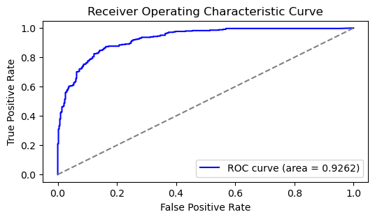

```python
# get predicted hit probability
y_probs = rf.predict_proba(X_test)[:, 1]

# calculate ROC curve and AUC
fpr, tpr, thresholds = roc_curve(y_test, y_probs)
roc_auc = auc(fpr, tpr)

# plot the ROC curve vs diagonal line
plt.figure(figsize = (6, 3))
plt.plot(fpr, tpr, color = 'blue', label = f'ROC curve (area = {round(roc_auc, 4)})')
plt.plot([0, 1], [0, 1], color='gray', linestyle='--')
plt.xlabel('False Positive Rate')
plt.ylabel('True Positive Rate')
plt.title('Receiver Operating Characteristic Curve')
plt.legend(loc='lower right')
plt.show()
```

- The AUC is about 0.9262, which I am very happy about.
- We will now check which variables were most important in creating the model.

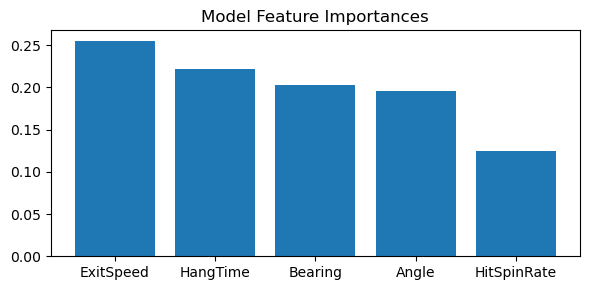

```python
# get the feature importances for our model and display a bar plot
importances = rf.feature_importances_
feature_names = X_train.columns
indices = importances.argsort()[::-1]

plt.figure(figsize=(6, 3))
plt.title("Model Feature Importances")
plt.bar(range(X_train.shape[1]), importances[indices], align="center")
plt.xticks(range(X_train.shape[1]), feature_names[indices], rotation=0)
plt.tight_layout()
plt.show()
```

- It seems that exit speed and hang time are the best indicators of a hit.